# FP-c-somani

## Electric Vehicle Python Project

Student Name: Aditi Somani

Data Set Name: Electric Vehicle Population Data

Data Set Source Address(URL): https://catalog.data.gov/dataset/electric-vehicle-population-data

Data Set Description: This dataset shows the Battery Electric Vehicles (BEVs) and Plug-in Hybrid Electric Vehicles (PHEVs) that are currently registered through Washington State Department of Licensing (DOL).

### Variable Definitions

| Serial Number | Variable Name | Variable Definition |
| --- | --- | --- |
| 1 | VIN (1-10) | Vehicle Identification Number of the Electric Vehicle |
| 2 | County | Specific region of a state |
| 3 | City | City of Electric Vehicle |
| 4 | State | State of Washington |
| 5 | Postal Code | Mailing Zip code |
| 6 | Model Year | Electric Vehicle Model Released Year |
| 7 | Make | Electric Vehicle Brand Name |
| 8 | Model | Electric Vehicle Brand Model |
| 9 | Electric Vehicle Type | Battery / Plug-in Hybrid EV Type |
| 10 | Clean Alternative Fuel Vehicle (CAFV) Eligibility | EV Fuel Alternative Eligibility |
| 11 | Electric Range | The range of EV |
| 12 | Base MSRP | The cost price of Electric Vehicle |
| 13 | Legislative District | EV governing district |
| 14 | DOL Vehicle ID | Department of Licensing Vehicle Identification |
| 15 | Vehicle Location | The location of EV |
| 16 | Electric Utility | EV distribution facilities |
| 17 | 2020 Census Tract | Statistical subdivisions of a EV county |

### Importing and Reading the Electric Vehicle Population Data Set

```python
import csv
import pandas as pd
import seaborn as sns
import matplotlib.pyplot as plt

df = pd.read_csv('Electric_Vehicle_Population_Data.csv')
```

```python
df #reading df(dataframe) which is Electric Vehicle Population Data
```

|  | VIN (1-10) | County | City | State | Postal Code | Model Year | Make | Model | Electric Vehicle Type | Clean Alternative Fuel Vehicle (CAFV) Eligibility | Electric Range | Base MSRP | Legislative District | DOL Vehicle ID | Vehicle Location | Electric Utility | 2020 Census Tract |
| --- | --- | --- | --- | --- | --- | --- | --- | --- | --- | --- | --- | --- | --- | --- | --- | --- | --- |
| 0 | 3MW5P9J05N | Arapahoe | Englewood | CO | 80111.0 | 2022 | BMW | 330E | Plug-in Hybrid Electric Vehicle (PHEV) | Not eligible due to low battery range | 22 | 0 | NaN | 200589147 | POINT (-104.89239 39.61914) | NaN | 8.005007e+09 |
| 1 | 5YJXCBE27J | Island | Greenbank | WA | 98253.0 | 2018 | TESLA | MODEL X | Battery Electric Vehicle (BEV) | Clean Alternative Fuel Vehicle Eligible | 238 | 0 | 10.0 | 326880081 | POINT (-122.575569 48.08489) | NaN | 5.302997e+10 |
| 2 | 1N4AZ0CP3F | Kings | Lemoore | CA | 93245.0 | 2015 | NISSAN | LEAF | Battery Electric Vehicle (BEV) | Clean Alternative Fuel Vehicle Eligible | 84 | 0 | NaN | 182237457 | POINT (-119.78637 36.30101) | NaN | 6.031980e+09 |
| 3 | 5YJ3E1EA8J | San Diego | Oceanside | CA | 92051.0 | 2018 | TESLA | MODEL 3 | Battery Electric Vehicle (BEV) | Clean Alternative Fuel Vehicle Eligible | 215 | 0 | NaN | 153998050 | NaN | NaN | 6.073019e+09 |
| 4 | 5YJ3E1EB1K | Alameda | Berkeley | CA | 94710.0 | 2019 | TESLA | MODEL 3 | Battery Electric Vehicle (BEV) | Clean Alternative Fuel Vehicle Eligible | 220 | 0 | NaN | 320914072 | POINT (-122.300531 37.869271) | NaN | 6.001423e+09 |
| ... | ... | ... | ... | ... | ... | ... | ... | ... | ... | ... | ... | ... | ... | ... | ... | ... | ... |
| 109476 | KM8K33AGXN | Whatcom | Bellingham | WA | 98229.0 | 2022 | HYUNDAI | KONA ELECTRIC | Battery Electric Vehicle (BEV) | Eligibility unknown as battery range has not b... | 0 | 0 | 40.0 | 176212200 | POINT (-122.414936 48.709388) | PUGET SOUND ENERGY INC\|\|PUD NO 1 OF WHATCOM CO... | 5.307300e+10 |
| 109477 | 5YJ3E1EB2N | King | Sammamish | WA | 98075.0 | 2022 | TESLA | MODEL 3 | Battery Electric Vehicle (BEV) | Eligibility unknown as battery range has not b... | 0 | 0 | 41.0 | 185637224 | POINT (-122.028168 47.586173) | PUGET SOUND ENERGY INC\|\|CITY OF TACOMA - (WA) | 5.303303e+10 |
| 109478 | 5YJYGDEE9M | Snohomish | Bothell | WA | 98021.0 | 2021 | TESLA | MODEL Y | Battery Electric Vehicle (BEV) | Eligibility unknown as battery range has not b... | 0 | 0 | 1.0 | 153892070 | POINT (-122.212105 47.792368) | PUGET SOUND ENERGY INC | 5.306105e+10 |
| 109479 | 1N4AZ1CP0J | King | Shoreline | WA | 98133.0 | 2018 | NISSAN | LEAF | Battery Electric Vehicle (BEV) | Clean Alternative Fuel Vehicle Eligible | 151 | 0 | 32.0 | 289064191 | POINT (-122.343983 47.739969) | CITY OF SEATTLE - (WA)\|CITY OF TACOMA - (WA) | 5.303302e+10 |
| 109480 | 5YJYGDEE2M | Benton | Richland | WA | 99354.0 | 2021 | TESLA | MODEL Y | Battery Electric Vehicle (BEV) | Eligibility unknown as battery range has not b... | 0 | 0 | 8.0 | 171199227 | POINT (-119.26844 46.31484) | BONNEVILLE POWER ADMINISTRATION\|\|CITY OF RICHL... | 5.300501e+10 |

109481 rows × 17 columns

### df.head(n): The head method returns the first/top n rows for the object based on position. It is useful for quickly testing if your object has the right type of data in it. If not mentioned, by default, it only shows top 5 rows.

```python
df.head()
```

|  | VIN (1-10) | County | City | State | Postal Code | Model Year | Make | Model | Electric Vehicle Type | Clean Alternative Fuel Vehicle (CAFV) Eligibility | Electric Range | Base MSRP | Legislative District | DOL Vehicle ID | Vehicle Location | Electric Utility | 2020 Census Tract |
| --- | --- | --- | --- | --- | --- | --- | --- | --- | --- | --- | --- | --- | --- | --- | --- | --- | --- |
| 0 | 3MW5P9J05N | Arapahoe | Englewood | CO | 80111.0 | 2022 | BMW | 330E | Plug-in Hybrid Electric Vehicle (PHEV) | Not eligible due to low battery range | 22 | 0 | NaN | 200589147 | POINT (-104.89239 39.61914) | NaN | 8.005007e+09 |
| 1 | 5YJXCBE27J | Island | Greenbank | WA | 98253.0 | 2018 | TESLA | MODEL X | Battery Electric Vehicle (BEV) | Clean Alternative Fuel Vehicle Eligible | 238 | 0 | 10.0 | 326880081 | POINT (-122.575569 48.08489) | NaN | 5.302997e+10 |
| 2 | 1N4AZ0CP3F | Kings | Lemoore | CA | 93245.0 | 2015 | NISSAN | LEAF | Battery Electric Vehicle (BEV) | Clean Alternative Fuel Vehicle Eligible | 84 | 0 | NaN | 182237457 | POINT (-119.78637 36.30101) | NaN | 6.031980e+09 |
| 3 | 5YJ3E1EA8J | San Diego | Oceanside | CA | 92051.0 | 2018 | TESLA | MODEL 3 | Battery Electric Vehicle (BEV) | Clean Alternative Fuel Vehicle Eligible | 215 | 0 | NaN | 153998050 | NaN | NaN | 6.073019e+09 |
| 4 | 5YJ3E1EB1K | Alameda | Berkeley | CA | 94710.0 | 2019 | TESLA | MODEL 3 | Battery Electric Vehicle (BEV) | Clean Alternative Fuel Vehicle Eligible | 220 | 0 | NaN | 320914072 | POINT (-122.300531 37.869271) | NaN | 6.001423e+09 |

### df.tail(n): The tail method returns the last/bottom n rows of the dataframe

```python
df.tail()
```

|  | VIN (1-10) | County | City | State | Postal Code | Model Year | Make | Model | Electric Vehicle Type | Clean Alternative Fuel Vehicle (CAFV) Eligibility | Electric Range | Base MSRP | Legislative District | DOL Vehicle ID | Vehicle Location | Electric Utility | 2020 Census Tract |
| --- | --- | --- | --- | --- | --- | --- | --- | --- | --- | --- | --- | --- | --- | --- | --- | --- | --- |
| 109476 | KM8K33AGXN | Whatcom | Bellingham | WA | 98229.0 | 2022 | HYUNDAI | KONA ELECTRIC | Battery Electric Vehicle (BEV) | Eligibility unknown as battery range has not b... | 0 | 0 | 40.0 | 176212200 | POINT (-122.414936 48.709388) | PUGET SOUND ENERGY INC\|\|PUD NO 1 OF WHATCOM CO... | 5.307300e+10 |
| 109477 | 5YJ3E1EB2N | King | Sammamish | WA | 98075.0 | 2022 | TESLA | MODEL 3 | Battery Electric Vehicle (BEV) | Eligibility unknown as battery range has not b... | 0 | 0 | 41.0 | 185637224 | POINT (-122.028168 47.586173) | PUGET SOUND ENERGY INC\|\|CITY OF TACOMA - (WA) | 5.303303e+10 |
| 109478 | 5YJYGDEE9M | Snohomish | Bothell | WA | 98021.0 | 2021 | TESLA | MODEL Y | Battery Electric Vehicle (BEV) | Eligibility unknown as battery range has not b... | 0 | 0 | 1.0 | 153892070 | POINT (-122.212105 47.792368) | PUGET SOUND ENERGY INC | 5.306105e+10 |
| 109479 | 1N4AZ1CP0J | King | Shoreline | WA | 98133.0 | 2018 | NISSAN | LEAF | Battery Electric Vehicle (BEV) | Clean Alternative Fuel Vehicle Eligible | 151 | 0 | 32.0 | 289064191 | POINT (-122.343983 47.739969) | CITY OF SEATTLE - (WA)\|CITY OF TACOMA - (WA) | 5.303302e+10 |
| 109480 | 5YJYGDEE2M | Benton | Richland | WA | 99354.0 | 2021 | TESLA | MODEL Y | Battery Electric Vehicle (BEV) | Eligibility unknown as battery range has not b... | 0 | 0 | 8.0 | 171199227 | POINT (-119.26844 46.31484) | BONNEVILLE POWER ADMINISTRATION\|\|CITY OF RICHL... | 5.300501e+10 |

### df.shape: The shape attribute returns a tuple representing the dimensionality of the Data Frame(df). For example, there are 109481 rows and 17 columns in the Electric Vehicle Population Data set that I have chosen.

```python
df.shape
```

```
(109481, 17)
```

### df.size: The size attribute returns the total number of values (i.e. rows x columns) in the data frame.

```python
df.size
```

```
1861177
```

### df.isnull().sum(): This method is used to detect the missing values in the dataset. By using, the sum() method alongside, it will give the number of column-wise missing values

```python
df.isnull().sum()
```

```
VIN (1-10)                                             0
County                                                 1
City                                                   1
State                                                  0
Postal Code                                            1
Model Year                                             0
Make                                                   0
Model                                                  7
Electric Vehicle Type                                  0
Clean Alternative Fuel Vehicle (CAFV) Eligibility      0
Electric Range                                         0
Base MSRP                                              0
Legislative District                                 276
DOL Vehicle ID                                         0
Vehicle Location                                      25
Electric Utility                                     428
2020 Census Tract                                      1
dtype: int64
```

### df.columns: This attribute diplays all the columns of the data frame

```python
#Displaying all the columns of the Electric Vehicle Data Set
for i,j in enumerate(df.columns,1):
    print(str(i).center(3),j)
```

```
 1  VIN (1-10)
 2  County
 3  City
 4  State
 5  Postal Code
 6  Model Year
 7  Make
 8  Model
 9  Electric Vehicle Type
 10 Clean Alternative Fuel Vehicle (CAFV) Eligibility
 11 Electric Range
 12 Base MSRP
 13 Legislative District
 14 DOL Vehicle ID
 15 Vehicle Location
 16 Electric Utility
 17 2020 Census Tract
```

### df.describe(): This method returns the Descriptive statistics include those that summarize the central tendency, dispersion and shape of a dataset’s distribution, excluding Not a Number(NaN) values.

```python
df.describe()
```

|  | Postal Code | Model Year | Electric Range | Base MSRP | Legislative District | DOL Vehicle ID | 2020 Census Tract |
| --- | --- | --- | --- | --- | --- | --- | --- |
| count | 109480.000000 | 109481.000000 | 109481.000000 | 109481.000000 | 109205.000000 | 1.094810e+05 | 1.094800e+05 |
| mean | 98157.012943 | 2018.899197 | 90.211425 | 1849.194609 | 29.824120 | 1.984476e+08 | 5.296849e+10 |
| std | 2640.605503 | 2.872853 | 102.575715 | 10946.085012 | 14.679959 | 9.561719e+07 | 1.675104e+09 |
| min | 1730.000000 | 1997.000000 | 0.000000 | 0.000000 | 1.000000 | 4.777000e+03 | 1.101001e+09 |
| 25% | 98052.000000 | 2017.000000 | 0.000000 | 0.000000 | 18.000000 | 1.467313e+08 | 5.303301e+10 |
| 50% | 98121.000000 | 2019.000000 | 35.000000 | 0.000000 | 34.000000 | 1.874118e+08 | 5.303303e+10 |
| 75% | 98370.000000 | 2021.000000 | 208.000000 | 0.000000 | 43.000000 | 2.169176e+08 | 5.305307e+10 |
| max | 99701.000000 | 2023.000000 | 337.000000 | 845000.000000 | 49.000000 | 4.792548e+08 | 5.603300e+10 |

### df.info(): This method returns both the data type and the number of non-null values for each column and the amount of memory taken by the data frame

```python
df.info()
```

```
<class 'pandas.core.frame.DataFrame'>
RangeIndex: 109481 entries, 0 to 109480
Data columns (total 17 columns):
 #   Column                                             Non-Null Count   Dtype
---  ------                                             --------------   -----
 0   VIN (1-10)                                         109481 non-null  object
 1   County                                             109480 non-null  object
 2   City                                               109480 non-null  object
 3   State                                              109481 non-null  object
 4   Postal Code                                        109480 non-null  float64
 5   Model Year                                         109481 non-null  int64
 6   Make                                               109481 non-null  object
 7   Model                                              109474 non-null  object
 8   Electric Vehicle Type                              109481 non-null  object
 9   Clean Alternative Fuel Vehicle (CAFV) Eligibility  109481 non-null  object
 10  Electric Range                                     109481 non-null  int64
 11  Base MSRP                                          109481 non-null  int64
 12  Legislative District                               109205 non-null  float64
 13  DOL Vehicle ID                                     109481 non-null  int64
 14  Vehicle Location                                   109456 non-null  object
 15  Electric Utility                                   109053 non-null  object
 16  2020 Census Tract                                  109480 non-null  float64
dtypes: float64(3), int64(4), object(10)
memory usage: 14.2+ MB
```

### df.dtypes: This attribute is used to check the data type of each and every column of the data set. The int64 data type represents a whole number without a decimal point. The float64 data type represents a number with a decimal point. The object data type represents a string

```python
df.dtypes
```

```
VIN (1-10)                                            object
County                                                object
City                                                  object
State                                                 object
Postal Code                                          float64
Model Year                                             int64
Make                                                  object
Model                                                 object
Electric Vehicle Type                                 object
Clean Alternative Fuel Vehicle (CAFV) Eligibility     object
Electric Range                                         int64
Base MSRP                                              int64
Legislative District                                 float64
DOL Vehicle ID                                         int64
Vehicle Location                                      object
Electric Utility                                      object
2020 Census Tract                                    float64
dtype: object
```

### df.value_counts(): This method Return a Series containing counts of unique values. The resulting object will be in descending order so that the first element is the most frequently-occurring element

```python
df['Make'].value_counts()
```

```
TESLA             49942
NISSAN            12848
CHEVROLET         10065
FORD               5658
BMW                4656
KIA                4375
TOYOTA             4336
VOLVO              2440
VOLKSWAGEN         2375
AUDI               2298
CHRYSLER           1783
HYUNDAI            1289
JEEP               1105
FIAT                822
PORSCHE             807
HONDA               794
RIVIAN              717
MINI                613
MITSUBISHI          588
POLESTAR            533
MERCEDES-BENZ       458
SMART               273
JAGUAR              222
LINCOLN             155
CADILLAC            108
SUBARU               58
LUCID MOTORS         48
LAND ROVER           38
LEXUS                31
FISKER               20
GENESIS              13
AZURE DYNAMICS        7
TH!NK                 3
BENTLEY               3
Name: Make, dtype: int64
```

## How many models of Electric Vehicle Type are present in the data frame ?

```python
EV_Type = df[['Electric Vehicle Type','Model']].groupby('Electric Vehicle Type').count().reset_index()
EV_Type
```

|  | Electric Vehicle Type | Model |
| --- | --- | --- |
| 0 | Battery Electric Vehicle (BEV) | 82812 |
| 1 | Plug-in Hybrid Electric Vehicle (PHEV) | 26662 |

### We can see that there are only 2 types of Electric Vehicle models. And the majority is Battery Electric Vehicle model. The less famous type is Plug-in Hybrid EV.

### Let us see the pictorial representation of above output in the form of a circular chart

[output not shown]

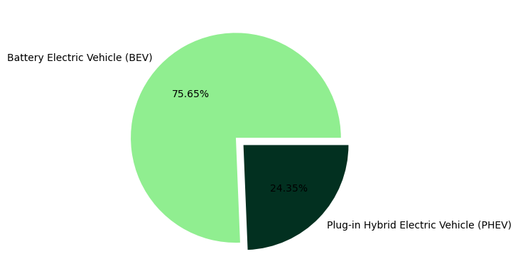

```python
explode = [0,0.1]
plt.pie(list(EV_Type['Model']),colors = ['#90EE90','#023020'],
        labels= list(EV_Type['Electric Vehicle Type']),
        explode=explode, autopct='%.2f%%')
```

### From the above pie chart, we can understand that there are 75.65% Battery EV and 24.35% Plug-in Hybrid EV.

```python
EV_Rise = df[['Model Year','Model']].groupby('Model Year').count().reset_index()
EV_Rise
```

|  | Model Year | Model |
| --- | --- | --- |
| 0 | 1997 | 1 |
| 1 | 1998 | 1 |
| 2 | 1999 | 4 |
| 3 | 2000 | 10 |
| 4 | 2002 | 2 |
| 5 | 2008 | 25 |
| 6 | 2010 | 25 |
| 7 | 2011 | 834 |
| 8 | 2012 | 1708 |
| 9 | 2013 | 4708 |
| 10 | 2014 | 3680 |
| 11 | 2015 | 4957 |
| 12 | 2016 | 5758 |
| 13 | 2017 | 8656 |
| 14 | 2018 | 14313 |
| 15 | 2019 | 10173 |
| 16 | 2020 | 11048 |
| 17 | 2021 | 18409 |
| 18 | 2022 | 24728 |
| 19 | 2023 | 434 |

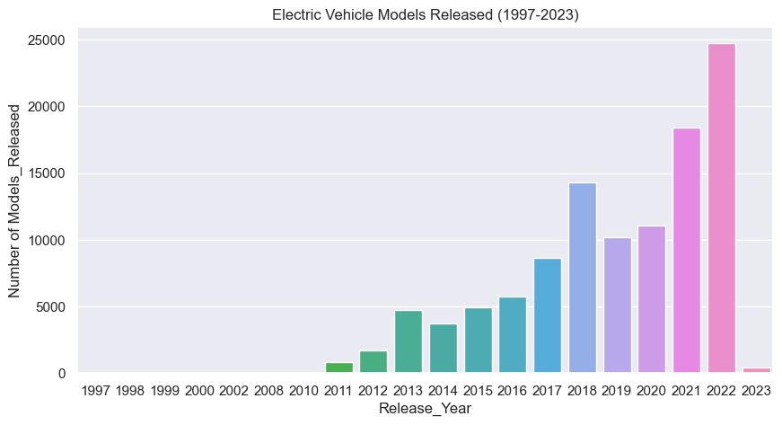

```python
sns.set(rc = {'figure.figsize':(10,5)})
sns.barplot(data= EV_Rise,x='Model Year',y='Model')
plt.xlabel("Release_Year")
plt.ylabel("Number of Models_Released")
plt.title("Electric Vehicle Models Released (1997-2023)")
```

### From the above bar graph, we can see the rise of Electric Vehicles and it will continue to increase in the near future as the natural resource petrol and diesel get exhausted. We must move towards green and pollution free options of commuting, also considering the global warming issue in mind.

## Sources:

https://pandas.pydata.org/pandas-docs/stable/user_guide/10min.html

https://realpython.com/pandas-dataframe/

https://www.kaggle.com/datasets

https://catalog.data.gov/dataset?res_format=CSV

https://medium.com/codex/10-efficient-ways-for-inspecting-a-pandas-dataframe-object-3f66563e2f2

https://towardsdatascience.com/building-bar-charts-using-matplotlib-c7cf6db3e728

https://www.geeksforgeeks.org/python-pandas-index-value_counts/